# Trabajo Práctico 1

Ankudowicz Santiago y Ferrero Kevin

## Introducción

Los datos corresponden a reseñas de vinos publicadas en la revista Wine Enthusiast.

Los datos originales fueron extraídos de [Kaggle](https://www.kaggle.com/zynicide/wine-reviews), que los obtuvo desde Wine Enthusiast la semana del 15 de junio de 2017. Luego fueron traducidos. En este informe estamos utilizando un archivo csv tal como fue provisto por el docente de la materia.

```r
# Código para cargar o leer los datos
vinos <- read.csv("datos/vinos.csv")
```

```r
# Listo los países de los que provienen los vinos reseñados y detallo cuantos provienen de cada país
vinos |> count(pais)
```

```
##                    pais     n
## 1              Alemania  2165
## 2             Argentina  3800
## 3               Armenia     2
## 4             Australia  2329
## 5               Austria  3345
## 6  Bosnia y Herzegovina     2
## 7                Brazil    52
## 8              Bulgaria   141
## 9                Canadá   257
## 10                Chile  4472
## 11                China     1
## 12               Chipre    11
## 13              Croacia    73
## 14               Egipto     1
```

[output cut: 30 more lines]

## Exploración de los datos

¿Qué variables tiene? Tiene 10 variables

Puedo usar la función ´ls()´ para listar las variables

```r
ls(vinos)
```

```
##  [1] "nombre"        "pais"          "precio"        "provincia"
##  [5] "puntos"        "region_1"      "region_2"      "titulo_resena"
##  [9] "variedad"      "vina"
```

También se puede usar la función ´str()´

```r
str(vinos)
```

```
## 'data.frame':    129971 obs. of  10 variables:
##  $ pais         : chr  "Italia" "Portugal" "Estados Unidos" "Estados Unidos" ...
##  $ nombre       : chr  "Vulkà Bianco" "Avidagos" NA "Reserve Late Harvest" ...
##  $ puntos       : int  87 87 87 87 87 87 87 87 87 87 ...
##  $ precio       : int  NA 15 14 13 65 15 16 24 12 27 ...
##  $ provincia    : chr  "Sicily & Sardinia" "Douro" "Oregon" "Michigan" ...
##  $ region_1     : chr  "Etna" NA "Willamette Valley" "Lake Michigan Shore" ...
##  $ region_2     : chr  NA NA "Willamette Valley" NA ...
##  $ variedad     : chr  "Ensamblaje Blanco" "Portuguese Red" "Pinot Gris" "Riesling" ...
##  $ vina         : chr  "Nicosia" "Quinta dos Avidagos" "Rainstorm" "St. Julian" ...
##  $ titulo_resena: chr  "Nicosia 2013 Vulkà Bianco  (Etna)" "Quinta dos Avidagos 2011 Avidagos Red (Douro)" "Rainstorm 2013 Pinot Gris (Willamette Valley)" "St. Julian 2013 Reserve Late Harvest Riesling (Lake Michigan Shore)" ...
```

¿Cuántas observaciones hay?

Tiene un total de 129.971 observaciones. El dato se puede obtener usando ´str()´. También se puede utilizar ´nrow()´.

```r
nrow(vinos)
```

```
## [1] 129971
```

Seleccioná algunas variables resulten interesantes y mostrá sus propiedades. - ¿Cuál es su valor medio y desvío estándard? - ¿Cuál es su rango (valor máximo y valor mínimo)? - ¿Hay alguna anomalía que sugiera que hay datos incorrectos? Valores imposibles (como valores negativos en una variable que sólo puede ser positiva) o poco creíbles. - ¿Cuántas observaciones hay por cada grupo? ¿Cuántos valores faltantes? ¿Hay diferencias?

Caracterizo la variable precio

```r
vinos|>
  summarise(precio_promedio = mean(precio, na.rm = TRUE),
            precio_desvest = sd(precio, na.rm = TRUE),
            precio_mín = min(precio, na.rm = TRUE),
            precio_máx = max(precio, na.rm = TRUE))
```

```
##   precio_promedio precio_desvest precio_mín precio_máx
## 1        35.36339       41.02222          4       3300
```

#Averiguo cuantos vinos tienen precio mayor a 1000

```r
count(filter(vinos, precio > 1000))
```

```
##    n
## 1 14
```

Caracterizo la variable puntos

```r
vinos|>
  summarise(puntaje_promedio = mean(puntos, na.rm = TRUE),
            puntaje_desvest = sd(puntos, na.rm = TRUE),
            puntaje_mín = min(puntos, na.rm = TRUE),
            puntaje_máx = max(puntos, na.rm = TRUE))
```

```
##   puntaje_promedio puntaje_desvest puntaje_mín puntaje_máx
## 1         88.44714         3.03973          80         100
```

```r
cantidad <- vinos |>
  group_by(precio) |>
  summarise(cantidad = n())
```

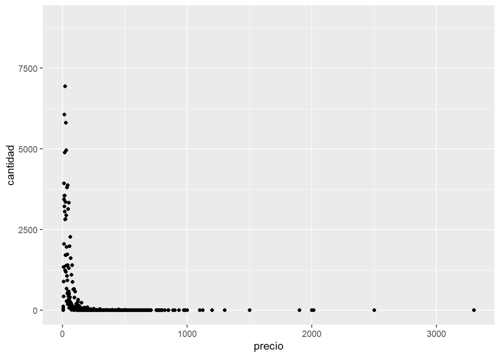

```r
ggplot(data = cantidad, mapping = aes(x = precio, y = cantidad))+
  geom_point()
```

```r
summary(vinos)
```

```
##      pais              nombre              puntos           precio
##  Length:129971      Length:129971      Min.   : 80.00   Min.   :   4.00
##  Class :character   Class :character   1st Qu.: 86.00   1st Qu.:  17.00
##  Mode  :character   Mode  :character   Median : 88.00   Median :  25.00
##                                        Mean   : 88.45   Mean   :  35.36
##                                        3rd Qu.: 91.00   3rd Qu.:  42.00
##                                        Max.   :100.00   Max.   :3300.00
##                                                         NA's   :8996
##   provincia           region_1           region_2           variedad
##  Length:129971      Length:129971      Length:129971      Length:129971
##  Class :character   Class :character   Class :character   Class :character
##  Mode  :character   Mode  :character   Mode  :character   Mode  :character
##
##
##
##
##      vina           titulo_resena
##  Length:129971      Length:129971
##  Class :character   Class :character
##  Mode  :character   Mode  :character
##
##
##
##
```

```r
vinos_nas <- vinos %>%
  summarise(pais_nas = sum(is.na(pais)), nombre_nas = sum(is.na(nombre)), puntos_nas = sum(is.na(puntos)), precio_nas = sum(is.na(precio)), provincia_nas = sum(is.na(provincia)), region_1_nas = sum(is.na(region_1)), region_2_nas = sum(is.na(region_2)), variedad_nas = sum(is.na(variedad)), vina_nas = sum(is.na(vina)), titulo_resena_nas = sum(is.na(titulo_resena)))
```

```r
vinos_variedad_nas <- vinos %>%
  group_by(variedad) %>%
  summarise(pais_nas = sum(is.na(pais)), nombre_nas = sum(is.na(nombre)), puntos_nas = sum(is.na(puntos)), precio_nas = sum(is.na(precio)), provincia_nas = sum(is.na(provincia)), region_1_nas = sum(is.na(region_1)), region_2_nas = sum(is.na(region_2)), variedad_nas = sum(is.na(variedad)), vina_nas = sum(is.na(vina)), titulo_resena_nas = sum(is.na(titulo_resena)))
```

```r
vinos_variedad_nas
```

```
## # A tibble: 708 × 11
##    variedad pais_nas nombre_nas puntos_nas precio_nas provincia_nas region_1_nas
##    <chr>       <int>      <int>      <int>      <int>         <int>        <int>
##  1 Abouriou        0          1          0          0             0            0
##  2 Agiorgi…        0         23          0          0             0           63
##  3 Agliani…        0         99          0         65             0            0
##  4 Aidani          0          0          0          0             0            1
##  5 Airen           0          1          0          0             0            0
##  6 Albana          0          1          0          4             0            1
##  7 Albanel…        0          0          0          0             0            0
##  8 Albariño        0        256          0          3             0            6
##  9 Albaros…        0          0          0          0             0            0
## 10 Aleatico        0          1          0          1             0            0
## # … with 698 more rows, and 4 more variables: region_2_nas <int>,
## #   variedad_nas <int>, vina_nas <int>, titulo_resena_nas <int>
```

```r
vinos_variedad_nas <- vinos %>%
  group_by(variedad) %>%
  summarise(cantidad_reseñas = sum(!is.na(puntos)), pais_nas = sum(is.na(pais)), nombre_nas = sum(is.na(nombre)), puntos_nas = sum(is.na(puntos)), precio_nas = sum(is.na(precio)), provincia_nas = sum(is.na(provincia)), region_1_nas = sum(is.na(region_1)), region_2_nas = sum(is.na(region_2)), variedad_nas = sum(is.na(variedad)), vina_nas = sum(is.na(vina)), titulo_resena_nas = sum(is.na(titulo_resena)))
```

```r
vinos_variedad_nas
```

```
## # A tibble: 708 × 12
##    variedad    cantidad_reseñas pais_nas nombre_nas puntos_nas precio_nas
##    <chr>                  <int>    <int>      <int>      <int>      <int>
##  1 Abouriou                   3        0          1          0          0
##  2 Agiorgitiko               63        0         23          0          0
##  3 Aglianico                359        0         99          0         65
##  4 Aidani                     1        0          0          0          0
##  5 Airen                      3        0          1          0          0
##  6 Albana                    23        0          1          0          4
##  7 Albanello                  1        0          0          0          0
##  8 Albariño                 477        0        256          0          3
##  9 Albarossa                  2        0          0          0          0
## 10 Aleatico                   5        0          1          0          1
## # … with 698 more rows, and 6 more variables: provincia_nas <int>,
## #   region_1_nas <int>, region_2_nas <int>, variedad_nas <int>, vina_nas <int>,
## #   titulo_resena_nas <int>
```

```r
vinos_pais_nas <- vinos %>%
  group_by(pais) %>%
  summarise(cantidad_reseñas = sum(!is.na(puntos)), pais_nas = sum(is.na(pais)), nombre_nas = sum(is.na(nombre)), puntos_nas = sum(is.na(puntos)), precio_nas = sum(is.na(precio)), provincia_nas = sum(is.na(provincia)), region_1_nas = sum(is.na(region_1)), region_2_nas = sum(is.na(region_2)), variedad_nas = sum(is.na(variedad)), vina_nas = sum(is.na(vina)), titulo_resena_nas = sum(is.na(titulo_resena)))
```

```r
vinos_pais_nas
```

```
## # A tibble: 44 × 12
##    pais               cantidad_reseñas pais_nas nombre_nas puntos_nas precio_nas
##    <chr>                         <int>    <int>      <int>      <int>      <int>
##  1 Alemania                       2165        0        159          0         45
##  2 Argentina                      3800        0        898          0         44
##  3 Armenia                           2        0          0          0          0
##  4 Australia                      2329        0        689          0         35
##  5 Austria                        3345        0        520          0        546
##  6 Bosnia y Herzegov…                2        0          1          0          0
##  7 Brazil                           52        0          1          0          5
##  8 Bulgaria                        141        0         48          0          0
##  9 Canadá                          257        0         78          0          3
## 10 Chile                          4472        0        593          0         56
## # … with 34 more rows, and 6 more variables: provincia_nas <int>,
## #   region_1_nas <int>, region_2_nas <int>, variedad_nas <int>, vina_nas <int>,
## #   titulo_resena_nas <int>
```

```r
vinos_pais_nas <- vinos_pais_nas |>
  mutate(proporción_nombre_nas = nombre_nas/cantidad_reseñas)
```

```r
select(vinos_pais_nas, pais, proporción_nombre_nas)
```

```
## # A tibble: 44 × 2
##    pais                 proporción_nombre_nas
##    <chr>                                <dbl>
##  1 Alemania                            0.0734
##  2 Argentina                           0.236
##  3 Armenia                             0
##  4 Australia                           0.296
##  5 Austria                             0.155
##  6 Bosnia y Herzegovina                0.5
##  7 Brazil                              0.0192
##  8 Bulgaria                            0.340
##  9 Canadá                              0.304
## 10 Chile                               0.133
## # … with 34 more rows
```

```r
vinos_pais <- vinos |>
  group_by(pais) |>
  summarise(precio_promedio = mean(precio, na.rm = TRUE))
```

```r
#Filter(vinos_pais_nas, pais == Brazil)
```

```r
distinct(vinos, pais)
```

```
##                    pais
## 1                Italia
## 2              Portugal
## 3        Estados Unidos
## 4                España
## 5               Francia
## 6              Alemania
## 7             Argentina
## 8                 Chile
## 9             Australia
## 10              Austria
## 11            Sudáfrica
## 12        Nueva Zelanda
## 13               Israel
## 14              Hungría
```

[output cut: 30 more lines]